# Optimal Treatment Analysis

## Outcome Variable

**Outcome Variable:** ever_wasted

## Predictor Variables

**Intervention Variable:** mhtcm

**Adjustment Set:**

- arm
- W_mage
- meducyrs
- feducyrs
- single
- delta_W_mage
- delta_meducyrs
- delta_feducyrs
- delta_single

## Stratifying Variables

The analysis was stratified on these variable(s):

- agecat
- studyid
- country

## Data Summary

| agecat | studyid | country | mhtcm | ever_wasted | n_cell | n |
| --- | --- | --- | --- | --- | --- | --- |
| 0-24 months | ki0047075b-MAL-ED | BANGLADESH | >=155 cm | 0 | 19 | 254 |
| 0-24 months | ki0047075b-MAL-ED | BANGLADESH | >=155 cm | 1 | 6 | 254 |
| 0-24 months | ki0047075b-MAL-ED | BANGLADESH | <151 cm | 0 | 104 | 254 |
| 0-24 months | ki0047075b-MAL-ED | BANGLADESH | <151 cm | 1 | 59 | 254 |
| 0-24 months | ki0047075b-MAL-ED | BANGLADESH | [151-155) cm | 0 | 46 | 254 |
| 0-24 months | ki0047075b-MAL-ED | BANGLADESH | [151-155) cm | 1 | 20 | 254 |
| 0-24 months | ki0047075b-MAL-ED | BRAZIL | >=155 cm | 0 | 116 | 222 |
| 0-24 months | ki0047075b-MAL-ED | BRAZIL | >=155 cm | 1 | 14 | 222 |
| 0-24 months | ki0047075b-MAL-ED | BRAZIL | <151 cm | 0 | 49 | 222 |
| 0-24 months | ki0047075b-MAL-ED | BRAZIL | <151 cm | 1 | 4 | 222 |
| 0-24 months | ki0047075b-MAL-ED | BRAZIL | [151-155) cm | 0 | 38 | 222 |
| 0-24 months | ki0047075b-MAL-ED | BRAZIL | [151-155) cm | 1 | 1 | 222 |
| 0-24 months | ki0047075b-MAL-ED | INDIA | >=155 cm | 0 | 31 | 242 |
| 0-24 months | ki0047075b-MAL-ED | INDIA | >=155 cm | 1 | 24 | 242 |
| 0-24 months | ki0047075b-MAL-ED | INDIA | <151 cm | 0 | 57 | 242 |
| 0-24 months | ki0047075b-MAL-ED | INDIA | <151 cm | 1 | 58 | 242 |
| 0-24 months | ki0047075b-MAL-ED | INDIA | [151-155) cm | 0 | 39 | 242 |
| 0-24 months | ki0047075b-MAL-ED | INDIA | [151-155) cm | 1 | 33 | 242 |
| 0-24 months | ki0047075b-MAL-ED | NEPAL | >=155 cm | 0 | 34 | 238 |
| 0-24 months | ki0047075b-MAL-ED | NEPAL | >=155 cm | 1 | 7 | 238 |
| 0-24 months | ki0047075b-MAL-ED | NEPAL | <151 cm | 0 | 89 | 238 |
| 0-24 months | ki0047075b-MAL-ED | NEPAL | <151 cm | 1 | 44 | 238 |
| 0-24 months | ki0047075b-MAL-ED | NEPAL | [151-155) cm | 0 | 46 | 238 |
| 0-24 months | ki0047075b-MAL-ED | NEPAL | [151-155) cm | 1 | 18 | 238 |
| 0-24 months | ki0047075b-MAL-ED | PERU | >=155 cm | 0 | 57 | 290 |
| 0-24 months | ki0047075b-MAL-ED | PERU | >=155 cm | 1 | 3 | 290 |
| 0-24 months | ki0047075b-MAL-ED | PERU | <151 cm | 0 | 150 | 290 |
| 0-24 months | ki0047075b-MAL-ED | PERU | <151 cm | 1 | 19 | 290 |
| 0-24 months | ki0047075b-MAL-ED | PERU | [151-155) cm | 0 | 57 | 290 |
| 0-24 months | ki0047075b-MAL-ED | PERU | [151-155) cm | 1 | 4 | 290 |

[output cut: 378 more lines]

The following strata were considered:

- agecat: 0-24 months, studyid: ki0047075b-MAL-ED, country: BANGLADESH
- agecat: 0-24 months, studyid: ki0047075b-MAL-ED, country: BRAZIL
- agecat: 0-24 months, studyid: ki0047075b-MAL-ED, country: INDIA
- agecat: 0-24 months, studyid: ki0047075b-MAL-ED, country: NEPAL
- agecat: 0-24 months, studyid: ki0047075b-MAL-ED, country: PERU
- agecat: 0-24 months, studyid: ki0047075b-MAL-ED, country: SOUTH AFRICA
- agecat: 0-24 months, studyid: ki0047075b-MAL-ED, country: TANZANIA, UNITED REPUBLIC OF
- agecat: 0-24 months, studyid: ki1000304b-SAS-CompFeed, country: INDIA
- agecat: 0-24 months, studyid: ki1000304b-SAS-FoodSuppl, country: INDIA
- agecat: 0-24 months, studyid: ki1017093-NIH-Birth, country: BANGLADESH
- agecat: 0-24 months, studyid: ki1017093b-PROVIDE, country: BANGLADESH
- agecat: 0-24 months, studyid: ki1017093c-NIH-Crypto, country: BANGLADESH
- agecat: 0-24 months, studyid: ki1066203-TanzaniaChild2, country: TANZANIA, UNITED REPUBLIC OF
- agecat: 0-24 months, studyid: ki1101329-Keneba, country: GAMBIA
- agecat: 0-24 months, studyid: ki1112895-Guatemala BSC, country: GUATEMALA
- agecat: 0-24 months, studyid: ki1112895-iLiNS-Zinc, country: BURKINA FASO
- agecat: 0-24 months, studyid: ki1119695-PROBIT, country: BELARUS
- agecat: 0-24 months, studyid: ki1126311-ZVITAMBO, country: ZIMBABWE
- agecat: 0-24 months, studyid: ki1135781-COHORTS, country: GUATEMALA
- agecat: 0-24 months, studyid: ki1135781-COHORTS, country: INDIA
- agecat: 0-24 months, studyid: ki1135781-COHORTS, country: PHILIPPINES
- agecat: 0-24 months, studyid: ki1148112-LCNI-5, country: MALAWI
- agecat: 0-24 months, studyid: kiGH5241-JiVitA-3, country: BANGLADESH
- agecat: 0-6 months, studyid: ki0047075b-MAL-ED, country: BANGLADESH
- agecat: 0-6 months, studyid: ki0047075b-MAL-ED, country: BRAZIL
- agecat: 0-6 months, studyid: ki0047075b-MAL-ED, country: INDIA
- agecat: 0-6 months, studyid: ki0047075b-MAL-ED, country: NEPAL
- agecat: 0-6 months, studyid: ki0047075b-MAL-ED, country: PERU
- agecat: 0-6 months, studyid: ki0047075b-MAL-ED, country: SOUTH AFRICA
- agecat: 0-6 months, studyid: ki0047075b-MAL-ED, country: TANZANIA, UNITED REPUBLIC OF
- agecat: 0-6 months, studyid: ki1000304b-SAS-CompFeed, country: INDIA
- agecat: 0-6 months, studyid: ki1000304b-SAS-FoodSuppl, country: INDIA
- agecat: 0-6 months, studyid: ki1017093-NIH-Birth, country: BANGLADESH
- agecat: 0-6 months, studyid: ki1017093b-PROVIDE, country: BANGLADESH
- agecat: 0-6 months, studyid: ki1017093c-NIH-Crypto, country: BANGLADESH
- agecat: 0-6 months, studyid: ki1066203-TanzaniaChild2, country: TANZANIA, UNITED REPUBLIC OF
- agecat: 0-6 months, studyid: ki1101329-Keneba, country: GAMBIA
- agecat: 0-6 months, studyid: ki1112895-Guatemala BSC, country: GUATEMALA
- agecat: 0-6 months, studyid: ki1119695-PROBIT, country: BELARUS
- agecat: 0-6 months, studyid: ki1126311-ZVITAMBO, country: ZIMBABWE
- agecat: 0-6 months, studyid: ki1135781-COHORTS, country: GUATEMALA
- agecat: 0-6 months, studyid: ki1135781-COHORTS, country: INDIA
- agecat: 0-6 months, studyid: ki1135781-COHORTS, country: PHILIPPINES
- agecat: 0-6 months, studyid: ki1148112-LCNI-5, country: MALAWI
- agecat: 0-6 months, studyid: kiGH5241-JiVitA-3, country: BANGLADESH
- agecat: 6-24 months, studyid: ki0047075b-MAL-ED, country: BANGLADESH
- agecat: 6-24 months, studyid: ki0047075b-MAL-ED, country: BRAZIL
- agecat: 6-24 months, studyid: ki0047075b-MAL-ED, country: INDIA
- agecat: 6-24 months, studyid: ki0047075b-MAL-ED, country: NEPAL
- agecat: 6-24 months, studyid: ki0047075b-MAL-ED, country: PERU
- agecat: 6-24 months, studyid: ki0047075b-MAL-ED, country: SOUTH AFRICA
- agecat: 6-24 months, studyid: ki0047075b-MAL-ED, country: TANZANIA, UNITED REPUBLIC OF
- agecat: 6-24 months, studyid: ki1000304b-SAS-CompFeed, country: INDIA
- agecat: 6-24 months, studyid: ki1000304b-SAS-FoodSuppl, country: INDIA
- agecat: 6-24 months, studyid: ki1017093-NIH-Birth, country: BANGLADESH
- agecat: 6-24 months, studyid: ki1017093b-PROVIDE, country: BANGLADESH
- agecat: 6-24 months, studyid: ki1017093c-NIH-Crypto, country: BANGLADESH
- agecat: 6-24 months, studyid: ki1066203-TanzaniaChild2, country: TANZANIA, UNITED REPUBLIC OF
- agecat: 6-24 months, studyid: ki1101329-Keneba, country: GAMBIA
- agecat: 6-24 months, studyid: ki1112895-Guatemala BSC, country: GUATEMALA
- agecat: 6-24 months, studyid: ki1112895-iLiNS-Zinc, country: BURKINA FASO
- agecat: 6-24 months, studyid: ki1119695-PROBIT, country: BELARUS
- agecat: 6-24 months, studyid: ki1126311-ZVITAMBO, country: ZIMBABWE
- agecat: 6-24 months, studyid: ki1135781-COHORTS, country: GUATEMALA
- agecat: 6-24 months, studyid: ki1135781-COHORTS, country: INDIA
- agecat: 6-24 months, studyid: ki1135781-COHORTS, country: PHILIPPINES
- agecat: 6-24 months, studyid: ki1148112-LCNI-5, country: MALAWI
- agecat: 6-24 months, studyid: kiGH5241-JiVitA-3, country: BANGLADESH

### Dropped Strata

Some strata were dropped due to rare outcomes:

- agecat: 0-24 months, studyid: ki0047075b-MAL-ED, country: BRAZIL
- agecat: 0-24 months, studyid: ki0047075b-MAL-ED, country: PERU
- agecat: 0-24 months, studyid: ki0047075b-MAL-ED, country: SOUTH AFRICA
- agecat: 0-24 months, studyid: ki1112895-Guatemala BSC, country: GUATEMALA
- agecat: 0-6 months, studyid: ki0047075b-MAL-ED, country: BRAZIL
- agecat: 0-6 months, studyid: ki0047075b-MAL-ED, country: NEPAL
- agecat: 0-6 months, studyid: ki0047075b-MAL-ED, country: PERU
- agecat: 0-6 months, studyid: ki0047075b-MAL-ED, country: SOUTH AFRICA
- agecat: 0-6 months, studyid: ki0047075b-MAL-ED, country: TANZANIA, UNITED REPUBLIC OF
- agecat: 0-6 months, studyid: ki1000304b-SAS-FoodSuppl, country: INDIA
- agecat: 0-6 months, studyid: ki1112895-Guatemala BSC, country: GUATEMALA
- agecat: 0-6 months, studyid: ki1148112-LCNI-5, country: MALAWI
- agecat: 6-24 months, studyid: ki0047075b-MAL-ED, country: BANGLADESH
- agecat: 6-24 months, studyid: ki0047075b-MAL-ED, country: BRAZIL
- agecat: 6-24 months, studyid: ki0047075b-MAL-ED, country: PERU
- agecat: 6-24 months, studyid: ki0047075b-MAL-ED, country: SOUTH AFRICA
- agecat: 6-24 months, studyid: ki1112895-Guatemala BSC, country: GUATEMALA
- agecat: 6-24 months, studyid: ki1119695-PROBIT, country: BELARUS

## Methods Detail

We’re interested in the causal parameters $E[Y_a]$ for all values of $a \in \mathcal{A}$. These parameters represent the mean outcome if, possibly contrary to fact, we intervened to set all units to have $A=a$. Under the randomization and positivity assumptions, these are identified by the statistical parameters $\psi_a=E_W[E_{Y|A,W}(Y|A=a,W)]$. In addition, we’re interested in the mean of $Y$, $E[Y]$ under no intervention (the observed mean). We will estimate these parameters by using SuperLearner to fit the relevant likelihood factors – $E_{Y|A,W}(Y|A=a,W)$ and $p(A=a|W)$, and then updating our likelihood fit using a joint TMLE.

For unadjusted analyses ($W=\{\}$), initial likelihoods were estimated using Lrnr_glm to estimate the simple $E(Y|A)$ and Lrnr_mean to estimate $p(A)$. For adjusted analyses, a small library containing Lrnr_glmnet, Lrnr_xgboost, and Lrnr_mean was used.

Having estimated these parameters, we will then use the delta method to estimate relative risks and attributable risks relative to a prespecified baseline level of $A$.

# Results Detail

## Results Plots

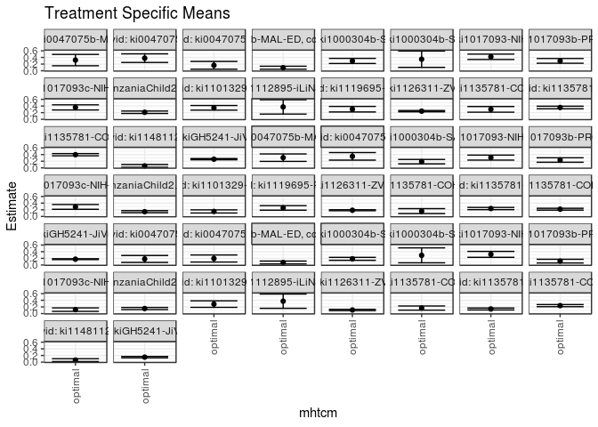

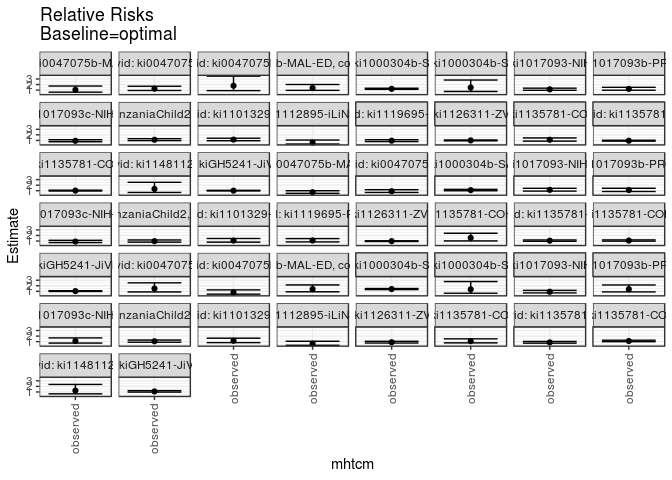

## Results Table

### Parameter: TSM

| agecat | studyid | country | intervention_level | baseline_level | estimate | ci_lower | ci_upper |
| --- | --- | --- | --- | --- | --- | --- | --- |
| 0-24 months | ki0047075b-MAL-ED | BANGLADESH | optimal | NA | 0.3200972 | 0.1500420 | 0.4901524 |
| 0-24 months | ki0047075b-MAL-ED | INDIA | optimal | NA | 0.3776716 | 0.2479078 | 0.5074354 |
| 0-24 months | ki0047075b-MAL-ED | NEPAL | optimal | NA | 0.1627420 | 0.0458726 | 0.2796115 |
| 0-24 months | ki0047075b-MAL-ED | TANZANIA, UNITED REPUBLIC OF | optimal | NA | 0.0904735 | 0.0447246 | 0.1362224 |
| 0-24 months | ki1000304b-SAS-CompFeed | INDIA | optimal | NA | 0.2943775 | 0.2179395 | 0.3708156 |
| 0-24 months | ki1000304b-SAS-FoodSuppl | INDIA | optimal | NA | 0.3467334 | 0.1013491 | 0.5921177 |
| 0-24 months | ki1017093-NIH-Birth | BANGLADESH | optimal | NA | 0.4194530 | 0.3389979 | 0.4999081 |
| 0-24 months | ki1017093b-PROVIDE | BANGLADESH | optimal | NA | 0.2966302 | 0.2252761 | 0.3679843 |
| 0-24 months | ki1017093c-NIH-Crypto | BANGLADESH | optimal | NA | 0.3578568 | 0.2801942 | 0.4355194 |
| 0-24 months | ki1066203-TanzaniaChild2 | TANZANIA, UNITED REPUBLIC OF | optimal | NA | 0.2118300 | 0.1749657 | 0.2486943 |
| 0-24 months | ki1101329-Keneba | GAMBIA | optimal | NA | 0.3457553 | 0.2752224 | 0.4162883 |
| 0-24 months | ki1112895-iLiNS-Zinc | BURKINA FASO | optimal | NA | 0.3724463 | 0.1575682 | 0.5873245 |
| 0-24 months | ki1119695-PROBIT | BELARUS | optimal | NA | 0.3037693 | 0.2203441 | 0.3871945 |
| 0-24 months | ki1126311-ZVITAMBO | ZIMBABWE | optimal | NA | 0.2445739 | 0.2248858 | 0.2642621 |
| 0-24 months | ki1135781-COHORTS | GUATEMALA | optimal | NA | 0.2994407 | 0.2145096 | 0.3843718 |
| 0-24 months | ki1135781-COHORTS | INDIA | optimal | NA | 0.3546164 | 0.3160735 | 0.3931592 |
| 0-24 months | ki1135781-COHORTS | PHILIPPINES | optimal | NA | 0.3960562 | 0.3623386 | 0.4297738 |
| 0-24 months | ki1148112-LCNI-5 | MALAWI | optimal | NA | 0.0597386 | 0.0185886 | 0.1008886 |
| 0-24 months | kiGH5241-JiVitA-3 | BANGLADESH | optimal | NA | 0.2612789 | 0.2434933 | 0.2790645 |
| 0-6 months | ki0047075b-MAL-ED | BANGLADESH | optimal | NA | 0.3067394 | 0.1949595 | 0.4185192 |
| 0-6 months | ki0047075b-MAL-ED | INDIA | optimal | NA | 0.3467143 | 0.2327574 | 0.4606712 |
| 0-6 months | ki1000304b-SAS-CompFeed | INDIA | optimal | NA | 0.1872293 | 0.1206957 | 0.2537629 |
| 0-6 months | ki1017093-NIH-Birth | BANGLADESH | optimal | NA | 0.3090960 | 0.2342082 | 0.3839837 |
| 0-6 months | ki1017093b-PROVIDE | BANGLADESH | optimal | NA | 0.2361970 | 0.1685573 | 0.3038367 |
| 0-6 months | ki1017093c-NIH-Crypto | BANGLADESH | optimal | NA | 0.2866483 | 0.2145845 | 0.3587122 |
| 0-6 months | ki1066203-TanzaniaChild2 | TANZANIA, UNITED REPUBLIC OF | optimal | NA | 0.1429660 | 0.1118080 | 0.1741241 |
| 0-6 months | ki1101329-Keneba | GAMBIA | optimal | NA | 0.1504527 | 0.1030199 | 0.1978854 |
| 0-6 months | ki1119695-PROBIT | BELARUS | optimal | NA | 0.2564932 | 0.1881641 | 0.3248223 |
| 0-6 months | ki1126311-ZVITAMBO | ZIMBABWE | optimal | NA | 0.1860805 | 0.1715564 | 0.2006046 |
| 0-6 months | ki1135781-COHORTS | GUATEMALA | optimal | NA | 0.1604893 | 0.0863592 | 0.2346194 |
| 0-6 months | ki1135781-COHORTS | INDIA | optimal | NA | 0.2378760 | 0.2045372 | 0.2712148 |
| 0-6 months | ki1135781-COHORTS | PHILIPPINES | optimal | NA | 0.2175745 | 0.1900814 | 0.2450676 |
| 0-6 months | kiGH5241-JiVitA-3 | BANGLADESH | optimal | NA | 0.1756028 | 0.1617713 | 0.1894343 |
| 6-24 months | ki0047075b-MAL-ED | INDIA | optimal | NA | 0.1818977 | 0.0775953 | 0.2862001 |
| 6-24 months | ki0047075b-MAL-ED | NEPAL | optimal | NA | 0.1950853 | 0.0888456 | 0.3013250 |
| 6-24 months | ki0047075b-MAL-ED | TANZANIA, UNITED REPUBLIC OF | optimal | NA | 0.0755767 | 0.0326127 | 0.1185407 |
| 6-24 months | ki1000304b-SAS-CompFeed | INDIA | optimal | NA | 0.1860607 | 0.1416751 | 0.2304463 |
| 6-24 months | ki1000304b-SAS-FoodSuppl | INDIA | optimal | NA | 0.2906572 | 0.0660989 | 0.5152154 |
| 6-24 months | ki1017093-NIH-Birth | BANGLADESH | optimal | NA | 0.3200264 | 0.2308140 | 0.4092388 |
| 6-24 months | ki1017093b-PROVIDE | BANGLADESH | optimal | NA | 0.1163625 | 0.0609654 | 0.1717597 |
| 6-24 months | ki1017093c-NIH-Crypto | BANGLADESH | optimal | NA | 0.1180638 | 0.0654082 | 0.1707193 |
| 6-24 months | ki1066203-TanzaniaChild2 | TANZANIA, UNITED REPUBLIC OF | optimal | NA | 0.1514242 | 0.1197151 | 0.1831334 |
| 6-24 months | ki1101329-Keneba | GAMBIA | optimal | NA | 0.2847955 | 0.1871113 | 0.3824797 |
| 6-24 months | ki1112895-iLiNS-Zinc | BURKINA FASO | optimal | NA | 0.3724463 | 0.1575682 | 0.5873245 |
| 6-24 months | ki1126311-ZVITAMBO | ZIMBABWE | optimal | NA | 0.1077535 | 0.0878899 | 0.1276170 |
| 6-24 months | ki1135781-COHORTS | GUATEMALA | optimal | NA | 0.1659238 | 0.1036077 | 0.2282399 |
| 6-24 months | ki1135781-COHORTS | INDIA | optimal | NA | 0.1388147 | 0.1097158 | 0.1679136 |
| 6-24 months | ki1135781-COHORTS | PHILIPPINES | optimal | NA | 0.2391685 | 0.2070409 | 0.2712962 |
| 6-24 months | ki1148112-LCNI-5 | MALAWI | optimal | NA | 0.0614014 | 0.0197366 | 0.1030662 |
| 6-24 months | kiGH5241-JiVitA-3 | BANGLADESH | optimal | NA | 0.1509017 | 0.1308393 | 0.1709641 |

### Parameter: E(Y)

| agecat | studyid | country | intervention_level | baseline_level | estimate | ci_lower | ci_upper |
| --- | --- | --- | --- | --- | --- | --- | --- |
| 0-24 months | ki0047075b-MAL-ED | BANGLADESH | observed | NA | 0.3346457 | 0.2765014 | 0.3927899 |
| 0-24 months | ki0047075b-MAL-ED | INDIA | observed | NA | 0.4752066 | 0.4121581 | 0.5382551 |
| 0-24 months | ki0047075b-MAL-ED | NEPAL | observed | NA | 0.2899160 | 0.2321510 | 0.3476810 |
| 0-24 months | ki0047075b-MAL-ED | TANZANIA, UNITED REPUBLIC OF | observed | NA | 0.1250000 | 0.0844083 | 0.1655917 |
| 0-24 months | ki1000304b-SAS-CompFeed | INDIA | observed | NA | 0.3609756 | 0.2943508 | 0.4276005 |
| 0-24 months | ki1000304b-SAS-FoodSuppl | INDIA | observed | NA | 0.5048544 | 0.4078263 | 0.6018825 |
| 0-24 months | ki1017093-NIH-Birth | BANGLADESH | observed | NA | 0.4775641 | 0.4383415 | 0.5167867 |
| 0-24 months | ki1017093b-PROVIDE | BANGLADESH | observed | NA | 0.3602392 | 0.3238339 | 0.3966444 |
| 0-24 months | ki1017093c-NIH-Crypto | BANGLADESH | observed | NA | 0.3311258 | 0.2975342 | 0.3647175 |
| 0-24 months | ki1066203-TanzaniaChild2 | TANZANIA, UNITED REPUBLIC OF | observed | NA | 0.2369648 | 0.2198019 | 0.2541277 |
| 0-24 months | ki1101329-Keneba | GAMBIA | observed | NA | 0.3958076 | 0.3763721 | 0.4152432 |
| 0-24 months | ki1112895-iLiNS-Zinc | BURKINA FASO | observed | NA | 0.2259307 | 0.1907517 | 0.2611097 |
| 0-24 months | ki1119695-PROBIT | BELARUS | observed | NA | 0.2876344 | 0.1859286 | 0.3893402 |
| 0-24 months | ki1126311-ZVITAMBO | ZIMBABWE | observed | NA | 0.2447609 | 0.2362612 | 0.2532607 |
| 0-24 months | ki1135781-COHORTS | GUATEMALA | observed | NA | 0.3354943 | 0.2982080 | 0.3727807 |
| 0-24 months | ki1135781-COHORTS | INDIA | observed | NA | 0.3338583 | 0.3126757 | 0.3550409 |
| 0-24 months | ki1135781-COHORTS | PHILIPPINES | observed | NA | 0.4036125 | 0.3861835 | 0.4210415 |
| 0-24 months | ki1148112-LCNI-5 | MALAWI | observed | NA | 0.0788530 | 0.0605839 | 0.0971222 |
| 0-24 months | kiGH5241-JiVitA-3 | BANGLADESH | observed | NA | 0.2641979 | 0.2551066 | 0.2732892 |
| 0-6 months | ki0047075b-MAL-ED | BANGLADESH | observed | NA | 0.2244094 | 0.1730022 | 0.2758167 |
| 0-6 months | ki0047075b-MAL-ED | INDIA | observed | NA | 0.3140496 | 0.2554513 | 0.3726479 |
| 0-6 months | ki1000304b-SAS-CompFeed | INDIA | observed | NA | 0.2078240 | 0.1493922 | 0.2662557 |
| 0-6 months | ki1017093-NIH-Birth | BANGLADESH | observed | NA | 0.3569132 | 0.3192325 | 0.3945938 |
| 0-6 months | ki1017093b-PROVIDE | BANGLADESH | observed | NA | 0.2630792 | 0.2296894 | 0.2964690 |
| 0-6 months | ki1017093c-NIH-Crypto | BANGLADESH | observed | NA | 0.2582781 | 0.2270370 | 0.2895193 |
| 0-6 months | ki1066203-TanzaniaChild2 | TANZANIA, UNITED REPUBLIC OF | observed | NA | 0.1394659 | 0.1254831 | 0.1534487 |
| 0-6 months | ki1101329-Keneba | GAMBIA | observed | NA | 0.1622128 | 0.1465647 | 0.1778610 |
| 0-6 months | ki1119695-PROBIT | BELARUS | observed | NA | 0.2824074 | 0.1800545 | 0.3847603 |
| 0-6 months | ki1126311-ZVITAMBO | ZIMBABWE | observed | NA | 0.1822082 | 0.1745617 | 0.1898546 |
| 0-6 months | ki1135781-COHORTS | GUATEMALA | observed | NA | 0.2505010 | 0.2124450 | 0.2885570 |
| 0-6 months | ki1135781-COHORTS | INDIA | observed | NA | 0.2528180 | 0.2330767 | 0.2725593 |
| 0-6 months | ki1135781-COHORTS | PHILIPPINES | observed | NA | 0.2355453 | 0.2204685 | 0.2506222 |
| 0-6 months | kiGH5241-JiVitA-3 | BANGLADESH | observed | NA | 0.1822104 | 0.1742135 | 0.1902074 |
| 6-24 months | ki0047075b-MAL-ED | INDIA | observed | NA | 0.2735043 | 0.2162683 | 0.3307402 |
| 6-24 months | ki0047075b-MAL-ED | NEPAL | observed | NA | 0.1531915 | 0.1070438 | 0.1993392 |
| 6-24 months | ki0047075b-MAL-ED | TANZANIA, UNITED REPUBLIC OF | observed | NA | 0.1061224 | 0.0674772 | 0.1447677 |
| 6-24 months | ki1000304b-SAS-CompFeed | INDIA | observed | NA | 0.2617801 | 0.2144185 | 0.3091417 |
| 6-24 months | ki1000304b-SAS-FoodSuppl | INDIA | observed | NA | 0.3921569 | 0.2969402 | 0.4873736 |
| 6-24 months | ki1017093-NIH-Birth | BANGLADESH | observed | NA | 0.2939002 | 0.2554778 | 0.3323226 |
| 6-24 months | ki1017093b-PROVIDE | BANGLADESH | observed | NA | 0.1612378 | 0.1321259 | 0.1903497 |
| 6-24 months | ki1017093c-NIH-Crypto | BANGLADESH | observed | NA | 0.1315068 | 0.1069744 | 0.1560393 |
| 6-24 months | ki1066203-TanzaniaChild2 | TANZANIA, UNITED REPUBLIC OF | observed | NA | 0.1617128 | 0.1455117 | 0.1779140 |
| 6-24 months | ki1101329-Keneba | GAMBIA | observed | NA | 0.3288908 | 0.3097941 | 0.3479875 |
| 6-24 months | ki1112895-iLiNS-Zinc | BURKINA FASO | observed | NA | 0.2259307 | 0.1907517 | 0.2611097 |
| 6-24 months | ki1126311-ZVITAMBO | ZIMBABWE | observed | NA | 0.0964361 | 0.0901919 | 0.1026803 |
| 6-24 months | ki1135781-COHORTS | GUATEMALA | observed | NA | 0.1797153 | 0.1479435 | 0.2114871 |
| 6-24 months | ki1135781-COHORTS | INDIA | observed | NA | 0.1199132 | 0.1050778 | 0.1347486 |
| 6-24 months | ki1135781-COHORTS | PHILIPPINES | observed | NA | 0.2666429 | 0.2502871 | 0.2829988 |
| 6-24 months | ki1148112-LCNI-5 | MALAWI | observed | NA | 0.0765492 | 0.0583736 | 0.0947248 |
| 6-24 months | kiGH5241-JiVitA-3 | BANGLADESH | observed | NA | 0.1647321 | 0.1555996 | 0.1738646 |

### Parameter: RR

| agecat | studyid | country | intervention_level | baseline_level | estimate | ci_lower | ci_upper |
| --- | --- | --- | --- | --- | --- | --- | --- |
| 0-24 months | ki0047075b-MAL-ED | BANGLADESH | observed | optimal | 1.0454501 | 0.6298128 | 1.7353823 |
| 0-24 months | ki0047075b-MAL-ED | INDIA | observed | optimal | 1.2582534 | 0.9315518 | 1.6995314 |
| 0-24 months | ki0047075b-MAL-ED | NEPAL | observed | optimal | 1.7814450 | 0.9062056 | 3.5020158 |
| 0-24 months | ki0047075b-MAL-ED | TANZANIA, UNITED REPUBLIC OF | observed | optimal | 1.3816202 | 0.9502069 | 2.0089039 |
| 0-24 months | ki1000304b-SAS-CompFeed | INDIA | observed | optimal | 1.2262337 | 1.1294033 | 1.3313659 |
| 0-24 months | ki1000304b-SAS-FoodSuppl | INDIA | observed | optimal | 1.4560304 | 0.7542557 | 2.8107504 |
| 0-24 months | ki1017093-NIH-Birth | BANGLADESH | observed | optimal | 1.1385402 | 0.9617259 | 1.3478620 |
| 0-24 months | ki1017093b-PROVIDE | BANGLADESH | observed | optimal | 1.2144386 | 0.9785653 | 1.5071668 |
| 0-24 months | ki1017093c-NIH-Crypto | BANGLADESH | observed | optimal | 0.9253026 | 0.7633472 | 1.1216194 |
| 0-24 months | ki1066203-TanzaniaChild2 | TANZANIA, UNITED REPUBLIC OF | observed | optimal | 1.1186556 | 0.9568045 | 1.3078851 |
| 0-24 months | ki1101329-Keneba | GAMBIA | observed | optimal | 1.1447622 | 0.9400446 | 1.3940620 |
| 0-24 months | ki1112895-iLiNS-Zinc | BURKINA FASO | observed | optimal | 0.6066127 | 0.3451603 | 1.0661103 |
| 0-24 months | ki1119695-PROBIT | BELARUS | observed | optimal | 0.9468845 | 0.7929861 | 1.1306506 |
| 0-24 months | ki1126311-ZVITAMBO | ZIMBABWE | observed | optimal | 1.0007646 | 0.9307414 | 1.0760559 |
| 0-24 months | ki1135781-COHORTS | GUATEMALA | observed | optimal | 1.1204032 | 0.8682022 | 1.4458650 |
| 0-24 months | ki1135781-COHORTS | INDIA | observed | optimal | 0.9414632 | 0.8615906 | 1.0287404 |
| 0-24 months | ki1135781-COHORTS | PHILIPPINES | observed | optimal | 1.0190788 | 0.9470488 | 1.0965872 |
| 0-24 months | ki1148112-LCNI-5 | MALAWI | observed | optimal | 1.3199685 | 0.6925509 | 2.5157961 |
| 0-24 months | kiGH5241-JiVitA-3 | BANGLADESH | observed | optimal | 1.0111718 | 0.9537264 | 1.0720774 |
| 0-6 months | ki0047075b-MAL-ED | BANGLADESH | observed | optimal | 0.7315965 | 0.5364921 | 0.9976539 |
| 0-6 months | ki0047075b-MAL-ED | INDIA | observed | optimal | 0.9057878 | 0.6930672 | 1.1837981 |
| 0-6 months | ki1000304b-SAS-CompFeed | INDIA | observed | optimal | 1.1099968 | 0.9946669 | 1.2386989 |
| 0-6 months | ki1017093-NIH-Birth | BANGLADESH | observed | optimal | 1.1547003 | 0.9317594 | 1.4309839 |
| 0-6 months | ki1017093b-PROVIDE | BANGLADESH | observed | optimal | 1.1138127 | 0.8622639 | 1.4387462 |
| 0-6 months | ki1017093c-NIH-Crypto | BANGLADESH | observed | optimal | 0.9010279 | 0.7213284 | 1.1254947 |
| 0-6 months | ki1066203-TanzaniaChild2 | TANZANIA, UNITED REPUBLIC OF | observed | optimal | 0.9755177 | 0.8017643 | 1.1869258 |
| 0-6 months | ki1101329-Keneba | GAMBIA | observed | optimal | 1.0781654 | 0.8016199 | 1.4501144 |
| 0-6 months | ki1119695-PROBIT | BELARUS | observed | optimal | 1.1010329 | 0.8442464 | 1.4359238 |
| 0-6 months | ki1126311-ZVITAMBO | ZIMBABWE | observed | optimal | 0.9791900 | 0.9171648 | 1.0454099 |
| 0-6 months | ki1135781-COHORTS | GUATEMALA | observed | optimal | 1.5608579 | 1.0167255 | 2.3961997 |
| 0-6 months | ki1135781-COHORTS | INDIA | observed | optimal | 1.0628143 | 0.9472889 | 1.1924284 |
| 0-6 months | ki1135781-COHORTS | PHILIPPINES | observed | optimal | 1.0825962 | 0.9717286 | 1.2061131 |
| 0-6 months | kiGH5241-JiVitA-3 | BANGLADESH | observed | optimal | 1.0376285 | 0.9721574 | 1.1075087 |
| 6-24 months | ki0047075b-MAL-ED | INDIA | observed | optimal | 1.5036157 | 0.8929409 | 2.5319260 |
| 6-24 months | ki0047075b-MAL-ED | NEPAL | observed | optimal | 0.7852538 | 0.4892667 | 1.2603015 |
| 6-24 months | ki0047075b-MAL-ED | TANZANIA, UNITED REPUBLIC OF | observed | optimal | 1.4041689 | 0.9167476 | 2.1507450 |
| 6-24 months | ki1000304b-SAS-CompFeed | INDIA | observed | optimal | 1.4069608 | 1.3170294 | 1.5030330 |
| 6-24 months | ki1000304b-SAS-FoodSuppl | INDIA | observed | optimal | 1.3492075 | 0.6589819 | 2.7623838 |
| 6-24 months | ki1017093-NIH-Birth | BANGLADESH | observed | optimal | 0.9183624 | 0.7196827 | 1.1718906 |
| 6-24 months | ki1017093b-PROVIDE | BANGLADESH | observed | optimal | 1.3856503 | 0.8950173 | 2.1452399 |
| 6-24 months | ki1017093c-NIH-Crypto | BANGLADESH | observed | optimal | 1.1138630 | 0.7429657 | 1.6699168 |
| 6-24 months | ki1066203-TanzaniaChild2 | TANZANIA, UNITED REPUBLIC OF | observed | optimal | 1.0679457 | 0.8902341 | 1.2811328 |
| 6-24 months | ki1101329-Keneba | GAMBIA | observed | optimal | 1.1548315 | 0.8245161 | 1.6174769 |
| 6-24 months | ki1112895-iLiNS-Zinc | BURKINA FASO | observed | optimal | 0.6066127 | 0.3451603 | 1.0661103 |
| 6-24 months | ki1126311-ZVITAMBO | ZIMBABWE | observed | optimal | 0.8949695 | 0.7527933 | 1.0639978 |
| 6-24 months | ki1135781-COHORTS | GUATEMALA | observed | optimal | 1.0831196 | 0.7789295 | 1.5061032 |
| 6-24 months | ki1135781-COHORTS | INDIA | observed | optimal | 0.8638363 | 0.7252665 | 1.0288815 |
| 6-24 months | ki1135781-COHORTS | PHILIPPINES | observed | optimal | 1.1148746 | 0.9906667 | 1.2546554 |
| 6-24 months | ki1148112-LCNI-5 | MALAWI | observed | optimal | 1.2467010 | 0.6617986 | 2.3485443 |
| 6-24 months | kiGH5241-JiVitA-3 | BANGLADESH | observed | optimal | 1.0916518 | 0.9690621 | 1.2297497 |

### Parameter: PAR

| agecat | studyid | country | intervention_level | baseline_level | estimate | ci_lower | ci_upper |
| --- | --- | --- | --- | --- | --- | --- | --- |
| 0-24 months | ki0047075b-MAL-ED | BANGLADESH | optimal | NA | 0.0145485 | -0.1477587 | 0.1768556 |
| 0-24 months | ki0047075b-MAL-ED | INDIA | optimal | NA | 0.0975350 | -0.0151035 | 0.2101735 |
| 0-24 months | ki0047075b-MAL-ED | NEPAL | optimal | NA | 0.1271739 | 0.0160627 | 0.2382851 |
| 0-24 months | ki0047075b-MAL-ED | TANZANIA, UNITED REPUBLIC OF | optimal | NA | 0.0345265 | -0.0007026 | 0.0697556 |
| 0-24 months | ki1000304b-SAS-CompFeed | INDIA | optimal | NA | 0.0665981 | 0.0518967 | 0.0812995 |
| 0-24 months | ki1000304b-SAS-FoodSuppl | INDIA | optimal | NA | 0.1581210 | -0.0681959 | 0.3844378 |
| 0-24 months | ki1017093-NIH-Birth | BANGLADESH | optimal | NA | 0.0581111 | -0.0125731 | 0.1287953 |
| 0-24 months | ki1017093b-PROVIDE | BANGLADESH | optimal | NA | 0.0636090 | -0.0006208 | 0.1278387 |
| 0-24 months | ki1017093c-NIH-Crypto | BANGLADESH | optimal | NA | -0.0267310 | -0.0956240 | 0.0421620 |
| 0-24 months | ki1066203-TanzaniaChild2 | TANZANIA, UNITED REPUBLIC OF | optimal | NA | 0.0251348 | -0.0079714 | 0.0582410 |
| 0-24 months | ki1101329-Keneba | GAMBIA | optimal | NA | 0.0500523 | -0.0180656 | 0.1181702 |
| 0-24 months | ki1112895-iLiNS-Zinc | BURKINA FASO | optimal | NA | -0.1465157 | -0.3565556 | 0.0635242 |
| 0-24 months | ki1119695-PROBIT | BELARUS | optimal | NA | -0.0161349 | -0.0665162 | 0.0342464 |
| 0-24 months | ki1126311-ZVITAMBO | ZIMBABWE | optimal | NA | 0.0001870 | -0.0175539 | 0.0179279 |
| 0-24 months | ki1135781-COHORTS | GUATEMALA | optimal | NA | 0.0360536 | -0.0401982 | 0.1123054 |
| 0-24 months | ki1135781-COHORTS | INDIA | optimal | NA | -0.0207581 | -0.0522158 | 0.0106996 |
| 0-24 months | ki1135781-COHORTS | PHILIPPINES | optimal | NA | 0.0075563 | -0.0214775 | 0.0365900 |
| 0-24 months | ki1148112-LCNI-5 | MALAWI | optimal | NA | 0.0191145 | -0.0195986 | 0.0578275 |
| 0-24 months | kiGH5241-JiVitA-3 | BANGLADESH | optimal | NA | 0.0029190 | -0.0123624 | 0.0182004 |
| 0-6 months | ki0047075b-MAL-ED | BANGLADESH | optimal | NA | -0.0823299 | -0.1772337 | 0.0125738 |
| 0-6 months | ki0047075b-MAL-ED | INDIA | optimal | NA | -0.0326647 | -0.1257675 | 0.0604381 |
| 0-6 months | ki1000304b-SAS-CompFeed | INDIA | optimal | NA | 0.0205946 | 0.0027142 | 0.0384751 |
| 0-6 months | ki1017093-NIH-Birth | BANGLADESH | optimal | NA | 0.0478172 | -0.0185116 | 0.1141461 |
| 0-6 months | ki1017093b-PROVIDE | BANGLADESH | optimal | NA | 0.0268822 | -0.0336569 | 0.0874213 |
| 0-6 months | ki1017093c-NIH-Crypto | BANGLADESH | optimal | NA | -0.0283702 | -0.0921671 | 0.0354267 |
| 0-6 months | ki1066203-TanzaniaChild2 | TANZANIA, UNITED REPUBLIC OF | optimal | NA | -0.0035001 | -0.0315364 | 0.0245362 |
| 0-6 months | ki1101329-Keneba | GAMBIA | optimal | NA | 0.0117602 | -0.0328011 | 0.0563215 |
| 0-6 months | ki1119695-PROBIT | BELARUS | optimal | NA | 0.0259143 | -0.0489048 | 0.1007333 |
| 0-6 months | ki1126311-ZVITAMBO | ZIMBABWE | optimal | NA | -0.0038723 | -0.0160517 | 0.0083070 |
| 0-6 months | ki1135781-COHORTS | GUATEMALA | optimal | NA | 0.0900117 | 0.0205483 | 0.1594751 |
| 0-6 months | ki1135781-COHORTS | INDIA | optimal | NA | 0.0149420 | -0.0124359 | 0.0423199 |
| 0-6 months | ki1135781-COHORTS | PHILIPPINES | optimal | NA | 0.0179708 | -0.0055478 | 0.0414895 |
| 0-6 months | kiGH5241-JiVitA-3 | BANGLADESH | optimal | NA | 0.0066077 | -0.0048395 | 0.0180548 |
| 6-24 months | ki0047075b-MAL-ED | INDIA | optimal | NA | 0.0916066 | -0.0039346 | 0.1871477 |
| 6-24 months | ki0047075b-MAL-ED | NEPAL | optimal | NA | -0.0418938 | -0.1342543 | 0.0504667 |
| 6-24 months | ki0047075b-MAL-ED | TANZANIA, UNITED REPUBLIC OF | optimal | NA | 0.0305458 | -0.0032454 | 0.0643369 |
| 6-24 months | ki1000304b-SAS-CompFeed | INDIA | optimal | NA | 0.0757194 | 0.0680005 | 0.0834383 |
| 6-24 months | ki1000304b-SAS-FoodSuppl | INDIA | optimal | NA | 0.1014997 | -0.1065042 | 0.3095035 |
| 6-24 months | ki1017093-NIH-Birth | BANGLADESH | optimal | NA | -0.0261262 | -0.1042811 | 0.0520287 |
| 6-24 months | ki1017093b-PROVIDE | BANGLADESH | optimal | NA | 0.0448752 | -0.0064734 | 0.0962239 |
| 6-24 months | ki1017093c-NIH-Crypto | BANGLADESH | optimal | NA | 0.0134431 | -0.0344291 | 0.0613153 |
| 6-24 months | ki1066203-TanzaniaChild2 | TANZANIA, UNITED REPUBLIC OF | optimal | NA | 0.0102886 | -0.0172716 | 0.0378489 |
| 6-24 months | ki1101329-Keneba | GAMBIA | optimal | NA | 0.0440953 | -0.0518401 | 0.1400307 |
| 6-24 months | ki1112895-iLiNS-Zinc | BURKINA FASO | optimal | NA | -0.1465157 | -0.3565556 | 0.0635242 |
| 6-24 months | ki1126311-ZVITAMBO | ZIMBABWE | optimal | NA | -0.0113174 | -0.0299685 | 0.0073337 |
| 6-24 months | ki1135781-COHORTS | GUATEMALA | optimal | NA | 0.0137915 | -0.0409414 | 0.0685244 |
| 6-24 months | ki1135781-COHORTS | INDIA | optimal | NA | -0.0189015 | -0.0431806 | 0.0053775 |
| 6-24 months | ki1135781-COHORTS | PHILIPPINES | optimal | NA | 0.0274744 | -0.0007879 | 0.0557366 |
| 6-24 months | ki1148112-LCNI-5 | MALAWI | optimal | NA | 0.0151478 | -0.0238675 | 0.0541631 |
| 6-24 months | kiGH5241-JiVitA-3 | BANGLADESH | optimal | NA | 0.0138304 | -0.0041372 | 0.0317980 |

### Parameter: PAF

| agecat | studyid | country | intervention_level | baseline_level | estimate | ci_lower | ci_upper |
| --- | --- | --- | --- | --- | --- | --- | --- |
| 0-24 months | ki0047075b-MAL-ED | BANGLADESH | optimal | NA | 0.0434742 | -0.5877734 | 0.4237581 |
| 0-24 months | ki0047075b-MAL-ED | INDIA | optimal | NA | 0.2052475 | -0.0734776 | 0.4116025 |
| 0-24 months | ki0047075b-MAL-ED | NEPAL | optimal | NA | 0.4386579 | -0.1035024 | 0.7144502 |
| 0-24 months | ki0047075b-MAL-ED | TANZANIA, UNITED REPUBLIC OF | optimal | NA | 0.2762121 | -0.0524024 | 0.5022161 |
| 0-24 months | ki1000304b-SAS-CompFeed | INDIA | optimal | NA | 0.1844947 | 0.1145767 | 0.2488917 |
| 0-24 months | ki1000304b-SAS-FoodSuppl | INDIA | optimal | NA | 0.3132012 | -0.3258103 | 0.6442231 |
| 0-24 months | ki1017093-NIH-Birth | BANGLADESH | optimal | NA | 0.1216823 | -0.0397973 | 0.2580843 |
| 0-24 months | ki1017093b-PROVIDE | BANGLADESH | optimal | NA | 0.1765742 | -0.0219043 | 0.3365034 |
| 0-24 months | ki1017093c-NIH-Crypto | BANGLADESH | optimal | NA | -0.0807275 | -0.3100199 | 0.1084319 |
| 0-24 months | ki1066203-TanzaniaChild2 | TANZANIA, UNITED REPUBLIC OF | optimal | NA | 0.1060698 | -0.0451456 | 0.2354068 |
| 0-24 months | ki1101329-Keneba | GAMBIA | optimal | NA | 0.1264561 | -0.0637793 | 0.2826718 |
| 0-24 months | ki1112895-iLiNS-Zinc | BURKINA FASO | optimal | NA | -0.6484983 | -1.8972043 | 0.0620107 |
| 0-24 months | ki1119695-PROBIT | BELARUS | optimal | NA | -0.0560950 | -0.2610561 | 0.1155535 |
| 0-24 months | ki1126311-ZVITAMBO | ZIMBABWE | optimal | NA | 0.0007640 | -0.0744123 | 0.0706802 |
| 0-24 months | ki1135781-COHORTS | GUATEMALA | optimal | NA | 0.1074641 | -0.1518054 | 0.3083725 |
| 0-24 months | ki1135781-COHORTS | INDIA | optimal | NA | -0.0621764 | -0.1606440 | 0.0279374 |
| 0-24 months | ki1135781-COHORTS | PHILIPPINES | optimal | NA | 0.0187216 | -0.0559118 | 0.0880798 |
| 0-24 months | ki1148112-LCNI-5 | MALAWI | optimal | NA | 0.2424062 | -0.4439372 | 0.6025115 |
| 0-24 months | kiGH5241-JiVitA-3 | BANGLADESH | optimal | NA | 0.0110484 | -0.0485188 | 0.0672315 |
| 0-6 months | ki0047075b-MAL-ED | BANGLADESH | optimal | NA | -0.3668737 | -0.8639605 | -0.0023516 |
| 0-6 months | ki0047075b-MAL-ED | INDIA | optimal | NA | -0.1040113 | -0.4428615 | 0.1552613 |
| 0-6 months | ki1000304b-SAS-CompFeed | INDIA | optimal | NA | 0.0990965 | -0.0053617 | 0.1927013 |
| 0-6 months | ki1017093-NIH-Birth | BANGLADESH | optimal | NA | 0.1339744 | -0.0732384 | 0.3011801 |
| 0-6 months | ki1017093b-PROVIDE | BANGLADESH | optimal | NA | 0.1021830 | -0.1597378 | 0.3049504 |
| 0-6 months | ki1017093c-NIH-Crypto | BANGLADESH | optimal | NA | -0.1098436 | -0.3863311 | 0.1115018 |
| 0-6 months | ki1066203-TanzaniaChild2 | TANZANIA, UNITED REPUBLIC OF | optimal | NA | -0.0250967 | -0.2472493 | 0.1574874 |
| 0-6 months | ki1101329-Keneba | GAMBIA | optimal | NA | 0.0724985 | -0.2474741 | 0.3103992 |
| 0-6 months | ki1119695-PROBIT | BELARUS | optimal | NA | 0.0917619 | -0.1844884 | 0.3035842 |
| 0-6 months | ki1126311-ZVITAMBO | ZIMBABWE | optimal | NA | -0.0212522 | -0.0903166 | 0.0434374 |
| 0-6 months | ki1135781-COHORTS | GUATEMALA | optimal | NA | 0.3593267 | 0.0164503 | 0.5826725 |
| 0-6 months | ki1135781-COHORTS | INDIA | optimal | NA | 0.0591018 | -0.0556442 | 0.1613752 |
| 0-6 months | ki1135781-COHORTS | PHILIPPINES | optimal | NA | 0.0762946 | -0.0290939 | 0.1708904 |
| 0-6 months | kiGH5241-JiVitA-3 | BANGLADESH | optimal | NA | 0.0362639 | -0.0286400 | 0.0970726 |
| 6-24 months | ki0047075b-MAL-ED | INDIA | optimal | NA | 0.3349365 | -0.1198950 | 0.6050437 |
| 6-24 months | ki0047075b-MAL-ED | NEPAL | optimal | NA | -0.2734736 | -1.0438749 | 0.2065390 |
| 6-24 months | ki0047075b-MAL-ED | TANZANIA, UNITED REPUBLIC OF | optimal | NA | 0.2878350 | -0.0908127 | 0.5350448 |
| 6-24 months | ki1000304b-SAS-CompFeed | INDIA | optimal | NA | 0.2892481 | 0.2407155 | 0.3346786 |
| 6-24 months | ki1000304b-SAS-FoodSuppl | INDIA | optimal | NA | 0.2588242 | -0.5174924 | 0.6379938 |
| 6-24 months | ki1017093-NIH-Birth | BANGLADESH | optimal | NA | -0.0888948 | -0.3895012 | 0.1466780 |
| 6-24 months | ki1017093b-PROVIDE | BANGLADESH | optimal | NA | 0.2783172 | -0.1172968 | 0.5338517 |
| 6-24 months | ki1017093c-NIH-Crypto | BANGLADESH | optimal | NA | 0.1022235 | -0.3459572 | 0.4011678 |
| 6-24 months | ki1066203-TanzaniaChild2 | TANZANIA, UNITED REPUBLIC OF | optimal | NA | 0.0636228 | -0.1233001 | 0.2194408 |
| 6-24 months | ki1101329-Keneba | GAMBIA | optimal | NA | 0.1340728 | -0.2128326 | 0.3817531 |
| 6-24 months | ki1112895-iLiNS-Zinc | BURKINA FASO | optimal | NA | -0.6484983 | -1.8972043 | 0.0620107 |
| 6-24 months | ki1126311-ZVITAMBO | ZIMBABWE | optimal | NA | -0.1173565 | -0.3283859 | 0.0601484 |
| 6-24 months | ki1135781-COHORTS | GUATEMALA | optimal | NA | 0.0767410 | -0.2838133 | 0.3360349 |
| 6-24 months | ki1135781-COHORTS | INDIA | optimal | NA | -0.1576267 | -0.3788036 | 0.0280708 |
| 6-24 months | ki1135781-COHORTS | PHILIPPINES | optimal | NA | 0.1030381 | -0.0094212 | 0.2029684 |
| 6-24 months | ki1148112-LCNI-5 | MALAWI | optimal | NA | 0.1978830 | -0.5110337 | 0.5742043 |
| 6-24 months | kiGH5241-JiVitA-3 | BANGLADESH | optimal | NA | 0.0839570 | -0.0319257 | 0.1868264 |